# Regression

Franziska Löw

## Prepare Data

```r
# Word-topic probabilities
stmOut %>% tidy("beta") %>% filter(!is.na(topic)) -> posts.wtp
# Document-topic probabilities
stmOut %>% tidy("gamma") -> posts.dtp
```

```r
top_topics <-
  posts.dtp %>%
  group_by(document) %>%
  mutate(therank = rank(-gamma, ties.method = "random")) %>%
  filter(therank %in% 1) %>%
  select(- therank)
```

We classify each document based on which topic has the highest probability. To estimate the true effect of a topic, we delete documents where the highest topic probability is smaller than 0.5, as topic assignment is not ambiguous. This left us with 7740 documents.

```r
btw.reg <-
  btw %>%
  left_join(., btw2 %>%
              select(title.text, shares, url),
            by = "title.text")
```

```r
# filter documents with low posterior
btw.reg <-
  btw.reg %>%
  mutate(document = as.numeric(articleID)) %>%
  left_join(., top_topics, by="document") %>%
  filter(gamma > 0.5)

# generate new variables and reduce df
btw.reg %>%
  mutate(topic = factor(topic),
         site = factor(site),
         shares.dummy = factor(ifelse(shares==0,0,1))) %>%
  select(site, shares, shares.dummy, date, text_length, month,
         document, topic, gamma) -> btw.reg
```

## Description of Data

```r
summary(btw.reg)
```

```
##          site          shares        shares.dummy
##  bild.de   : 350   Min.   :    0.0   0   :3084
##  focus.de  :1015   1st Qu.:    0.0   1   :4597
##  spiegel.de: 848   Median :    6.0   NA's:  59
##  stern.de  :2461   Mean   :  470.8
##  welt.de   :2286   3rd Qu.:  189.0
##  zeit.de   : 780   Max.   :41301.0
##                    NA's   :59
##       date                      text_length          month
##  Min.   :2017-05-31 00:00:00   Min.   :   24.0   Min.   : 5.000
##  1st Qu.:2017-07-30 00:00:00   1st Qu.:  193.0   1st Qu.: 7.000
##  Median :2017-09-15 12:00:00   Median :  358.0   Median : 9.000
##  Mean   :2017-08-30 16:09:01   Mean   :  498.1   Mean   : 8.445
##  3rd Qu.:2017-10-03 02:00:00   3rd Qu.:  598.0   3rd Qu.:10.000
##  Max.   :2017-10-28 02:00:00   Max.   :14507.0   Max.   :10.000
##
##     document         topic          gamma
##  Min.   :    1   20     : 373   Min.   :0.5001
##  1st Qu.: 2781   29     : 373   1st Qu.:0.6323
##  Median : 5280   2      : 367   Median :0.7783
##  Mean   : 5317   14     : 350   Mean   :0.7730
##  3rd Qu.: 7917   7      : 323   3rd Qu.:0.9243
##  Max.   :10528   9      : 279   Max.   :0.9993
##                  (Other):5675
```

The distribution of the outcome can then be modeled in terms of two parameters, $\pi$ the probability of ‘always zero’, and $\mu$, the mean number of publications for those not in the ‘always zero’ group. A natural way to introduce covariates is to model the logit of the probability $\pi$ of always zero and the log of the mean $\mu$ for those not in the always zero class.

## Analysis

### Zero-inflated Poisson regression

```r
# filter NAs
btw.reg %>%
  filter(!is.na(shares)) -> btw.reg
```

```r
library(pscl)
m1 <- zeroinfl(shares ~ topic + site | topic + site + text_length, data = btw.reg)
summary(m1)
```

```
##
## Call:
## zeroinfl(formula = shares ~ topic + site | topic + site + text_length,
##     data = btw.reg)
##
## Pearson residuals:
##      Min       1Q   Median       3Q      Max
## -42.3508  -1.9191  -0.7322  -0.3831 331.9427
##
## Count model coefficients (poisson with log link):
##                 Estimate Std. Error z value Pr(>|z|)
## (Intercept)     7.117680   0.003348 2125.77   <2e-16 ***
## topic2         -0.944554   0.004208 -224.45   <2e-16 ***
## topic3         -1.850519   0.007676 -241.08   <2e-16 ***
## topic4          0.617881   0.004001  154.44   <2e-16 ***
## topic5         -1.121086   0.023833  -47.04   <2e-16 ***
## topic6          0.135758   0.003502   38.77   <2e-16 ***
## topic7         -0.780910   0.004581 -170.48   <2e-16 ***
## topic8         -0.156916   0.003896  -40.28   <2e-16 ***
## topic9          0.377869   0.003409  110.85   <2e-16 ***
## topic10        -0.918428   0.005425 -169.29   <2e-16 ***
## topic11        -0.855270   0.005188 -164.85   <2e-16 ***
## topic12        -0.186556   0.004105  -45.44   <2e-16 ***
## topic13        -1.242750   0.005733 -216.79   <2e-16 ***
## topic14        -1.349675   0.005957 -226.56   <2e-16 ***
## topic15        -1.795723   0.007856 -228.57   <2e-16 ***
## topic16        -0.449171   0.004431 -101.38   <2e-16 ***
## topic17        -1.176309   0.010361 -113.53   <2e-16 ***
## topic18        -0.742978   0.004822 -154.09   <2e-16 ***
## topic19        -0.537716   0.004729 -113.71   <2e-16 ***
## topic20         0.226796   0.003344   67.81   <2e-16 ***
## topic21        -1.075803   0.004914 -218.93   <2e-16 ***
## topic22         0.514145   0.003798  135.37   <2e-16 ***
## topic23        -2.170447   0.009104 -238.41   <2e-16 ***
## topic24        -0.570781   0.006057  -94.24   <2e-16 ***
## topic25        -1.009268   0.005689 -177.42   <2e-16 ***
## topic26        -0.634459   0.004778 -132.77   <2e-16 ***
## topic27        -0.095552   0.004200  -22.75   <2e-16 ***
## topic28         0.166639   0.003933   42.37   <2e-16 ***
## topic29        -1.061653   0.004810 -220.72   <2e-16 ***
```

[output cut: 55 more lines]

```
## topic37        -0.0991607  0.4068300  -0.244 0.807432
## topic38        -1.8038124  0.7349992  -2.454 0.014121 *
## topic39        -0.1838591  0.4367347  -0.421 0.673765
## topic40        -1.8244062  0.8117703  -2.247 0.024612 *
## sitefocus.de    1.9172675  0.3366227   5.696 1.23e-08 ***
## sitespiegel.de -2.0097263  0.6630042  -3.031 0.002435 **
## sitestern.de    4.7763851  0.3302667  14.462  < 2e-16 ***
## sitewelt.de     3.2316906  0.3287509   9.830  < 2e-16 ***
## sitezeit.de     1.2525240  0.3506960   3.572 0.000355 ***
## text_length    -0.0024195  0.0001139 -21.244  < 2e-16 ***
## ---
## Signif. codes:  0 '***' 0.001 '**' 0.01 '*' 0.05 '.' 0.1 ' ' 1
##
## Number of iterations in BFGS optimization: 104
## Log-likelihood: -4.282e+06 on 91 Df
```

Looking at the inflate equation we see that some topics are significant predictors of being in the ‘always zero’ class.

To verify that the model solves the problem of excess zeroes we predict π and μ, and calculate the combined probability of no publications. There are options in the predict() function called “zero” and “count” to obtain these. There’s also an option “prob” to compute the predicted density, but this is overkill as we only want the probability of zero.

```r
pr <- predict(m1, type = "zero") # π
mu <- predict(m1, type= "count") # μ

zip <- pr+(1-pr)*exp(-mu)
mean(zip)
```

```
## [1] 0.4015147
```

Note that the model output above does not indicate in any way if our zero-inflated model is an improvement over a standard Poisson regression. We can determine this by running the corresponding standard Poisson model and then performing a Vuong test of the two models.

```r
p1 <- glm(shares ~ topic, family = poisson, data = btw.reg)
summary(p1)
```

```
##
## Call:
## glm(formula = shares ~ topic, family = poisson, data = btw.reg)
##
## Deviance Residuals:
##    Min      1Q  Median      3Q     Max
## -52.69  -28.36  -20.46   -9.93  497.58
##
## Coefficients:
##              Estimate Std. Error z value Pr(>|z|)
## (Intercept)  6.934009   0.002873 2413.38  < 2e-16 ***
## topic2      -1.241701   0.004192 -296.24  < 2e-16 ***
## topic3      -2.415582   0.007649 -315.80  < 2e-16 ***
## topic4       0.124293   0.003951   31.46  < 2e-16 ***
## topic5      -2.274462   0.023777  -95.66  < 2e-16 ***
## topic6      -0.095866   0.003488  -27.48  < 2e-16 ***
## topic7      -1.426628   0.004562 -312.70  < 2e-16 ***
## topic8      -0.153915   0.003891  -39.55  < 2e-16 ***
## topic9       0.089303   0.003390   26.34  < 2e-16 ***
## topic10     -0.928773   0.005416 -171.50  < 2e-16 ***
## topic11     -1.540512   0.005178 -297.52  < 2e-16 ***
## topic12     -0.130191   0.004090  -31.84  < 2e-16 ***
## topic13     -1.589983   0.005723 -277.83  < 2e-16 ***
## topic14     -2.271216   0.005932 -382.90  < 2e-16 ***
## topic15     -2.418177   0.007848 -308.12  < 2e-16 ***
## topic16     -0.577096   0.004426 -130.38  < 2e-16 ***
## topic17     -1.914459   0.010338 -185.19  < 2e-16 ***
## topic18     -1.160573   0.004809 -241.31  < 2e-16 ***
## topic19     -0.953002   0.004721 -201.85  < 2e-16 ***
## topic20     -0.021689   0.003306   -6.56 5.37e-11 ***
## topic21     -1.508632   0.004909 -307.35  < 2e-16 ***
## topic22     -0.284002   0.003763  -75.46  < 2e-16 ***
## topic23     -2.733111   0.009099 -300.37  < 2e-16 ***
## topic24     -1.090606   0.006033 -180.77  < 2e-16 ***
## topic25     -1.508413   0.005673 -265.90  < 2e-16 ***
## topic26     -1.250198   0.004767 -262.25  < 2e-16 ***
## topic27     -0.666651   0.004184 -159.32  < 2e-16 ***
## topic28     -0.375659   0.003895  -96.44  < 2e-16 ***
## topic29     -1.727716   0.004795 -360.32  < 2e-16 ***
## topic30     -0.904928   0.004898 -184.75  < 2e-16 ***
## topic31      0.301731   0.003489   86.49  < 2e-16 ***
## topic32     -0.609735   0.004093 -148.99  < 2e-16 ***
## topic33     -0.901386   0.004487 -200.89  < 2e-16 ***
## topic34     -0.937078   0.004642 -201.86  < 2e-16 ***
## topic35     -0.421695   0.005156  -81.78  < 2e-16 ***
## topic36     -1.220962   0.004578 -266.71  < 2e-16 ***
## topic37     -1.380602   0.005883 -234.67  < 2e-16 ***
## topic38     -2.665417   0.019409 -137.33  < 2e-16 ***
## topic39     -1.649573   0.007459 -221.15  < 2e-16 ***
## topic40     -0.502773   0.010148  -49.54  < 2e-16 ***
## ---
## Signif. codes:  0 '***' 0.001 '**' 0.01 '*' 0.05 '.' 0.1 ' ' 1
##
## (Dispersion parameter for poisson family taken to be 1)
##
##     Null deviance: 14178277  on 7680  degrees of freedom
## Residual deviance: 12323808  on 7641  degrees of freedom
## AIC: 12352967
##
## Number of Fisher Scoring iterations: 7
```

```r
vuong(p1, m1)
```

```
## NA or numerical zeros or ones encountered in fitted probabilities
## dropping these 1924 cases, but proceed with caution
## Vuong Non-Nested Hypothesis Test-Statistic:
## (test-statistic is asymptotically distributed N(0,1) under the
##  null that the models are indistinguishible)
## -------------------------------------------------------------
##               Vuong z-statistic             H_A    p-value
## Raw                   -27.17532 model2 > model1 < 2.22e-16
## AIC-corrected         -27.17267 model2 > model1 < 2.22e-16
## BIC-corrected         -27.16385 model2 > model1 < 2.22e-16
```

The Vuong test compares the zero-inflated model with an ordinary Poisson regression model. We can see that our test statistic is significant, indicating that the zero-inflated model is superior to the standard Poisson model.

### Plot the residuals

```r
btw.reg$predicted <- predict(m1)
btw.reg$residuals <- residuals(m1)
```

#### Residual Plot for multiple Variables

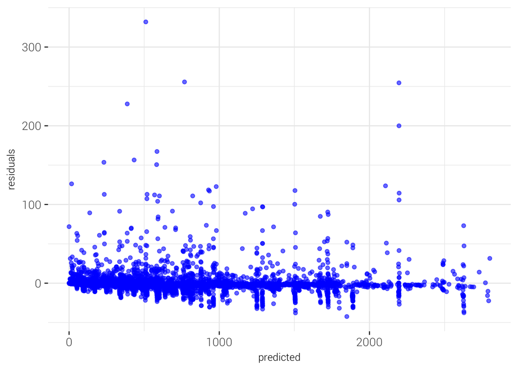

```r
ggplot(btw.reg, aes(predicted, residuals)) +
  geom_point(color="blue", alpha=0.6)
```

#### Residual Plot for single Variables

The predicted values are plotted in black. They are connected to the actual data points through a line and high residuals (in abolsute terms) are made more red on actual values. This helps to identify non-linearity in the data. We can see that there is more red for extreme values for spiegel.de as well as for the topics 12, 21 and 9.

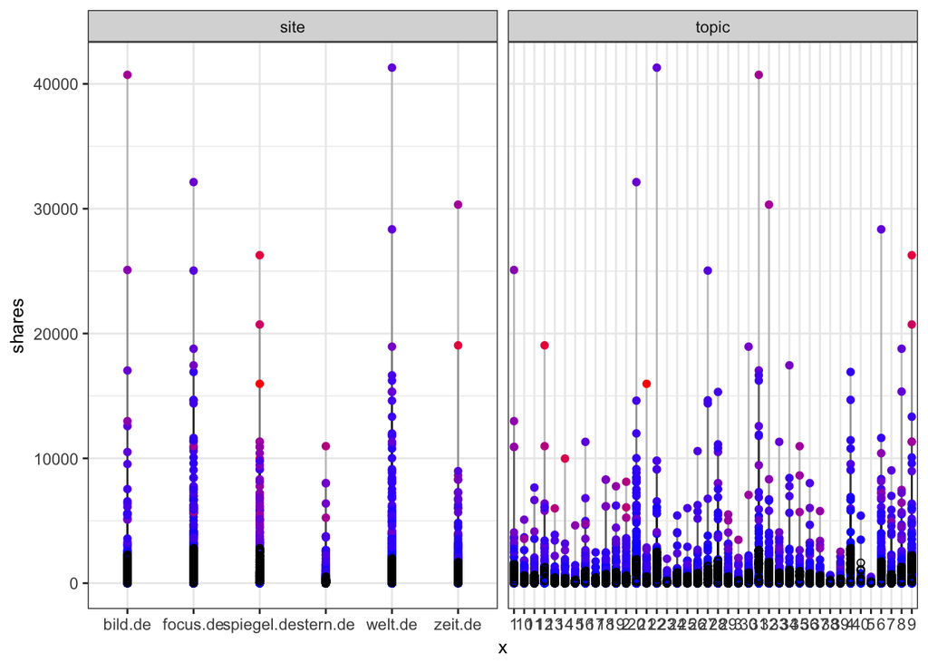

```r
btw.reg %>%
  select(site, shares, topic, residuals, predicted) %>%
  gather(key="iv", value="x", -shares, -predicted, -residuals) %>%
  ggplot(aes(x=x, y=shares)) +
  geom_segment(aes(xend=x, yend=predicted), alpha=.2) +
  geom_point(aes(color=residuals)) +
  scale_color_gradient2(low="black", mid="blue", high="red") +
  guides(color=FALSE) +
  geom_point(aes(y=predicted), shape=1) +
  facet_grid(~iv, scales="free") +
  theme_bw()
```